# Homework 3

PSTAT 131/231

## Classification

For this assignment, we will be working with part of a [Kaggle data set](https://www.kaggle.com/c/titanic/overview) that was the subject of a machine learning competition and is often used for practicing ML models. The goal is classification; specifically, to predict which passengers would survive the [Titanic shipwreck](https://en.wikipedia.org/wiki/Titanic).

[figure not shown]

Fig. 1: RMS Titanic departing Southampton on April 10, 1912.

Load the data from `data/titanic.csv` into *R* and familiarize yourself with the variables it contains using the codebook (`data/titanic_codebook.txt`).

Notice that `survived` and `pclass` should be changed to factors. When changing `survived` to a factor, you may want to reorder the factor so that *“Yes”* is the first level.

Make sure you load the `tidyverse` and `tidymodels`!

*Remember that you’ll need to set a seed at the beginning of the document to reproduce your results.*

```r
set.seed(7)

titanic <- read.csv("C:/Users/gabri/Desktop/Desktop New/Desktop/PHD PROGRAM/2022 Q4 Fall Work/PStat 231/Labs/PStat231/PStat231_HW3_files/homework-3/data/titanic.csv", header=TRUE, sep=",")
data <- data.frame(titanic)
glimpse(data)
```

```
## Rows: 891
## Columns: 12
## $ passenger_id <int> 1, 2, 3, 4, 5, 6, 7, 8, 9, 10, 11, 12, 13, 14, 15, 16, 17…
## $ survived     <chr> "No", "Yes", "Yes", "Yes", "No", "No", "No", "No", "Yes",…
## $ pclass       <int> 3, 1, 3, 1, 3, 3, 1, 3, 3, 2, 3, 1, 3, 3, 3, 2, 3, 2, 3, …
## $ name         <chr> "Braund, Mr. Owen Harris", "Cumings, Mrs. John Bradley (F…
## $ sex          <chr> "male", "female", "female", "female", "male", "male", "ma…
## $ age          <dbl> 22, 38, 26, 35, 35, NA, 54, 2, 27, 14, 4, 58, 20, 39, 14,…
## $ sib_sp       <int> 1, 1, 0, 1, 0, 0, 0, 3, 0, 1, 1, 0, 0, 1, 0, 0, 4, 0, 1, …
## $ parch        <int> 0, 0, 0, 0, 0, 0, 0, 1, 2, 0, 1, 0, 0, 5, 0, 0, 1, 0, 0, …
## $ ticket       <chr> "A/5 21171", "PC 17599", "STON/O2. 3101282", "113803", "3…
## $ fare         <dbl> 7.2500, 71.2833, 7.9250, 53.1000, 8.0500, 8.4583, 51.8625…
## $ cabin        <chr> NA, "C85", NA, "C123", NA, NA, "E46", NA, NA, NA, "G6", "…
## $ embarked     <chr> "S", "C", "S", "S", "S", "Q", "S", "S", "S", "C", "S", "S…
```

### Question 1

Split the data, stratifying on the outcome variable, `survived.` You should choose the proportions to split the data into. Verify that the training and testing data sets have the appropriate number of observations. Take a look at the training data and note any potential issues, such as missing data.

Why is it a good idea to use stratified sampling for this data?

```r
titanic_split <- titanic %>% initial_split(prop = 0.70,
                                strata = survived)
titanic_train <- training(titanic_split) #70% of the data
titanic_test <- testing(titanic_split)   #30% of the data

ntrain <- count(titanic_train)
ntest <- count(titanic_test)
ntrain/(ntrain+ntest)
```

```
##           n
## 1 0.6992144
```

### Question 2

Using the **training** data set, explore/describe the distribution of the outcome variable `survived`.

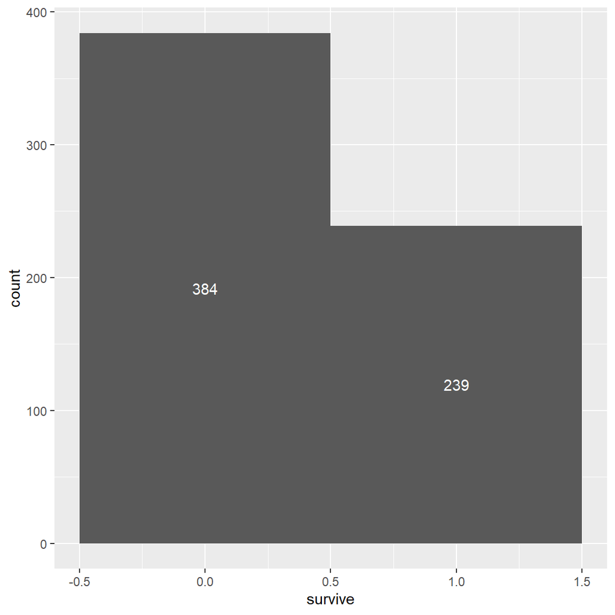

```r
titanic_train <- titanic_train %>% mutate(survive = as.numeric(as.factor(survived))-1)
titanic_train$survived <- as.factor(titanic_train$survived)

titanic_train %>%
  ggplot(aes(x = survive)) +
  geom_histogram(binwidth = 1) +
  stat_bin(binwidth = 1, geom="text",color="white",aes(label=..count..),position=position_stack(vjust=.5))
```

### Question 3

Using the **training** data set, create a correlation matrix of all continuous variables. Create a visualization of the matrix, and describe any patterns you see. Are any predictors correlated with each other? Which ones, and in which survived?

```r
summary(titanic_train)
```

```
##   passenger_id   survived      pclass         name               sex
##  Min.   :  1.0   No :384   Min.   :1.00   Length:623         Length:623
##  1st Qu.:215.5   Yes:239   1st Qu.:1.50   Class :character   Class :character
##  Median :432.0             Median :3.00   Mode  :character   Mode  :character
##  Mean   :438.0             Mean   :2.31
##  3rd Qu.:656.0             3rd Qu.:3.00
##  Max.   :891.0             Max.   :3.00
##
##       age            sib_sp           parch          ticket
##  Min.   : 0.67   Min.   :0.0000   Min.   :0.000   Length:623
##  1st Qu.:21.00   1st Qu.:0.0000   1st Qu.:0.000   Class :character
##  Median :29.00   Median :0.0000   Median :0.000   Mode  :character
##  Mean   :30.07   Mean   :0.5281   Mean   :0.366
##  3rd Qu.:38.00   3rd Qu.:1.0000   3rd Qu.:0.000
##  Max.   :74.00   Max.   :8.0000   Max.   :6.000
##  NA's   :122
##       fare            cabin             embarked            survive
##  Min.   :  0.000   Length:623         Length:623         Min.   :0.0000
##  1st Qu.:  7.925   Class :character   Class :character   1st Qu.:0.0000
##  Median : 14.500   Mode  :character   Mode  :character   Median :0.0000
##  Mean   : 31.779                                         Mean   :0.3836
##  3rd Qu.: 30.848                                         3rd Qu.:1.0000
##  Max.   :512.329                                         Max.   :1.0000
##
```

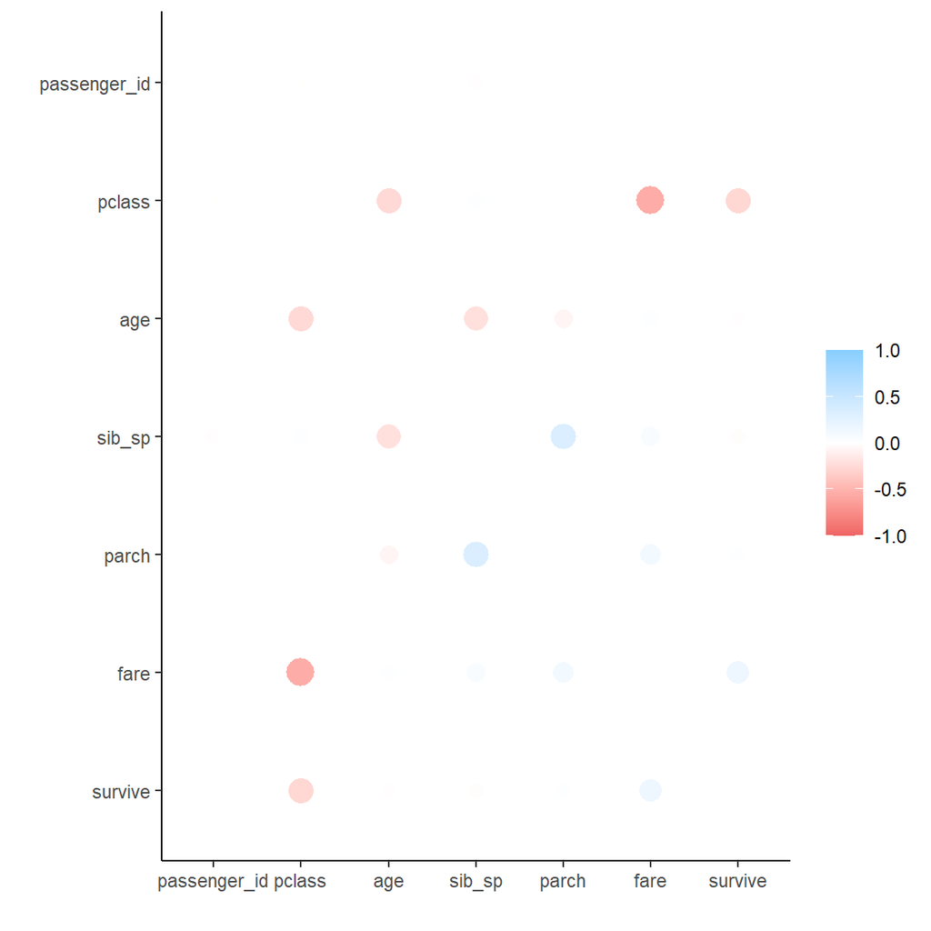

```r
cor_titanic <- titanic_train %>%
  #select(-c(survived,name,sex,ticket,cabin,embarked)) %>%
  correlate()
rplot(cor_titanic)
```

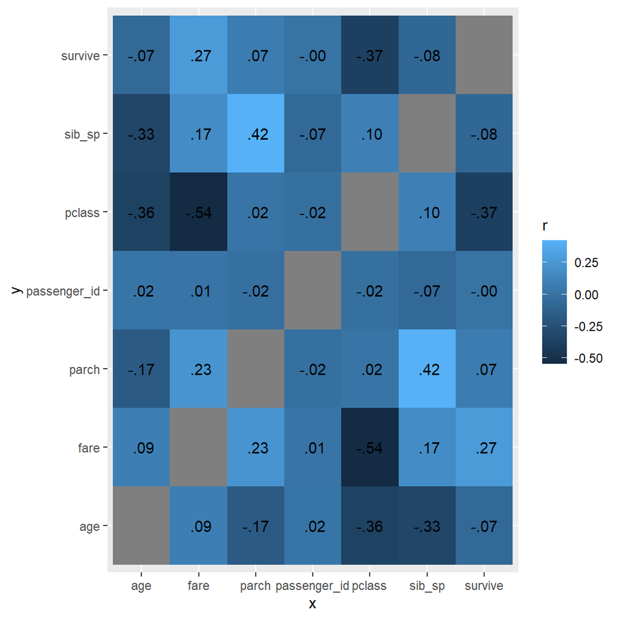

```r
cor_titanic %>%
  stretch() %>%
  ggplot(aes(x, y, fill = r)) +
  geom_tile() +
  geom_text(aes(label = as.character(fashion(r))))
```

parch seems strongly positively correlated with sib_sp which makes sense as a family endeavour. pclass is strongly negatively correlated with fare which makes sense because the highest fare should be in the lowest pclass value (1st) and the lowest fare should be associated with the highest pclass value (3rd).

pclass is negatively correlated with age, survive, and fare age is also negatively correlated with sib_sp, and parch sib_sp is also positively correlated to parch and fare fare is also positively correlated with parch and survive the rest appear negligibly correlated

### Question 4

Using the **training** data, create a recipe predicting the outcome variable `survived`. Include the following predictors: ticket class, sex, age, number of siblings or spouses aboard, number of parents or children aboard, and passenger fare.

Recall that there were missing values for `age`. To deal with this, add an imputation step using `step_impute_linear()`. Next, use `step_dummy()` to **dummy** encode categorical predictors. Finally, include interactions between:

- Sex and passenger fare, and
- Age and passenger fare.

You’ll need to investigate the `tidymodels` documentation to find the appropriate step functions to use.

```r
titanic_recipe <- recipe(survived ~ pclass + sex + age + sib_sp + parch + fare, titanic_train) %>%
  step_impute_linear(age, impute_with=imp_vars(sib_sp)) %>%
  step_dummy(all_nominal_predictors()) %>%
  step_interact(~ starts_with("sex"):fare + age:fare)
```

### Question 5

Specify a **logistic regression** model for classification using the `"glm"` engine. Then create a workflow. Add your model and the appropriate recipe. Finally, use `fit()` to apply your workflow to the **training** data.

*Hint: Make sure to store the results of `fit()`. You’ll need them later on.*

```r
log_reg <- logistic_reg() %>%
  set_engine("glm") %>%
  set_mode("classification")

log_wkflow <- workflow() %>%
  add_model(log_reg) %>%
  add_recipe(titanic_recipe)

log_fit <- fit(log_wkflow, titanic_train)

log_fit %>%
  tidy()
```

```
## # A tibble: 9 × 5
##   term             estimate std.error statistic  p.value
##   <chr>               <dbl>     <dbl>     <dbl>    <dbl>
## 1 (Intercept)      5.12      0.812        6.31  2.77e-10
## 2 pclass          -1.14      0.178       -6.39  1.62e-10
## 3 age             -0.0530    0.0131      -4.04  5.31e- 5
## 4 sib_sp          -0.664     0.158       -4.20  2.68e- 5
## 5 parch           -0.127     0.151       -0.842 4.00e- 1
## 6 fare             0.0217    0.0162       1.34  1.81e- 1
## 7 sex_male        -2.30      0.355       -6.47  9.67e-11
## 8 sex_male_x_fare -0.0236    0.0144      -1.63  1.02e- 1
## 9 fare_x_age       0.000184  0.000200     0.919 3.58e- 1
```

### Question 6

**Repeat Question 5**, but this time specify a linear discriminant analysis model for classification using the `"MASS"` engine.

```r
lda_mod <- discrim_linear() %>%
  set_mode("classification") %>%
  set_engine("MASS")

lda_wkflow <- workflow() %>%
  add_model(lda_mod) %>%
  add_recipe(titanic_recipe)

lda_fit <- fit(lda_wkflow, titanic_train)
```

### Question 7

**Repeat Question 5**, but this time specify a quadratic discriminant analysis model for classification using the `"MASS"` engine.

```r
qda_mod <- discrim_quad() %>%
  set_mode("classification") %>%
  set_engine("MASS")

qda_wkflow <- workflow() %>%
  add_model(qda_mod) %>%
  add_recipe(titanic_recipe)

qda_fit <- fit(qda_wkflow, titanic_train)
```

### Question 8

**Repeat Question 5**, but this time specify a naive Bayes model for classification using the `"klaR"` engine. Set the `usekernel` argument to `FALSE`.

```r
nb_mod <- naive_Bayes() %>%
  set_mode("classification") %>%
  set_engine("klaR") %>%
  set_args(usekernel = FALSE)

nb_wkflow <- workflow() %>%
  add_model(nb_mod) %>%
  add_recipe(titanic_recipe)

nb_fit <- fit(nb_wkflow, titanic_train)
```

### Question 9

Now you’ve fit four different models to your training data.

Use `predict()` and `bind_cols()` to generate predictions using each of these 4 models and your **training** data. Then use the *accuracy* metric to assess the performance of each of the four models.

Which model achieved the highest accuracy on the training data?

Logistic regression has the highest accuracy.

```r
#fit models: log_reg, lda_fit, qda_fit, nb_fit
names(titanic_train)
```

```
##  [1] "passenger_id" "survived"     "pclass"       "name"         "sex"
##  [6] "age"          "sib_sp"       "parch"        "ticket"       "fare"
## [11] "cabin"        "embarked"     "survive"
```

```r
#log_reg
predict(log_fit, new_data = titanic_train, type = "prob")
```

```
## # A tibble: 623 × 2
##    .pred_No .pred_Yes
##       <dbl>     <dbl>
##  1    0.916    0.0835
##  2    0.917    0.0832
##  3    0.906    0.0937
##  4    0.945    0.0553
##  5    0.836    0.164
##  6    0.978    0.0223
##  7    0.237    0.763
##  8    0.971    0.0289
##  9    0.524    0.476
## 10    0.583    0.417
## # … with 613 more rows
```

```r
augment(log_fit, new_data = titanic_train) %>%
  conf_mat(truth = survived, estimate = .pred_class)
```

```
##           Truth
## Prediction  No Yes
##        No  338  67
##        Yes  46 172
```

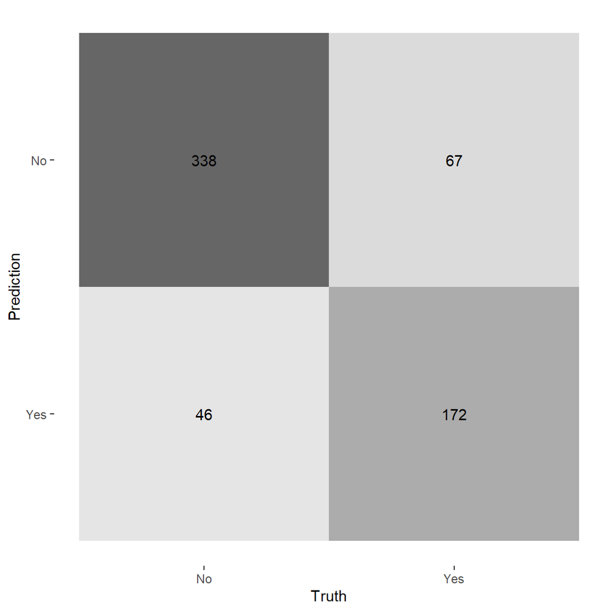

```r
augment(log_fit, new_data = titanic_train) %>%
  conf_mat(truth = survived, estimate = .pred_class) %>%
  autoplot(type = "heatmap")
```

```r
log_reg_acc <- augment(log_fit, new_data = titanic_train) %>%
  accuracy(truth = survived, estimate = .pred_class)
```

```r
predict(lda_fit, new_data = titanic_train, type = "prob")
```

```
## # A tibble: 623 × 2
##    .pred_No .pred_Yes
##       <dbl>     <dbl>
##  1    0.949    0.0514
##  2    0.955    0.0453
##  3    0.949    0.0511
##  4    0.952    0.0479
##  5    0.909    0.0914
##  6    0.983    0.0172
##  7    0.179    0.821
##  8    0.970    0.0298
##  9    0.449    0.551
## 10    0.443    0.557
## # … with 613 more rows
```

```r
augment(lda_fit, new_data = titanic_train) %>%
  conf_mat(truth = survived, estimate = .pred_class)
```

```
##           Truth
## Prediction  No Yes
##        No  332  71
##        Yes  52 168
```

```r
lda_acc <- augment(lda_fit, new_data = titanic_train) %>%
  accuracy(truth = survived, estimate = .pred_class)
```

```r
#qda
predict(qda_fit, new_data = titanic_train, type = "prob")
```

```
## # A tibble: 623 × 2
##    .pred_No    .pred_Yes
##       <dbl>        <dbl>
##  1   0.996  0.00352
##  2   0.997  0.00271
##  3   0.997  0.00319
##  4   1.00   0.0000110
##  5   0.994  0.00600
##  6   0.0658 0.934
##  7   0.401  0.599
##  8   1.00   0.0000000200
##  9   0.835  0.165
## 10   1.00   0.0000593
## # … with 613 more rows
```

```r
augment(qda_fit, new_data = titanic_train) %>%
  conf_mat(truth = survived, estimate = .pred_class)
```

```
##           Truth
## Prediction  No Yes
##        No  351 101
##        Yes  33 138
```

```r
qda_acc <- augment(qda_fit, new_data = titanic_train) %>%
  accuracy(truth = survived, estimate = .pred_class)
```

```r
#naive bayes
predict(nb_fit, new_data = titanic_train, type = "prob")
```

```
## # A tibble: 623 × 2
##    .pred_No   .pred_Yes
##       <dbl>       <dbl>
##  1    0.984 0.0155
##  2    0.982 0.0185
##  3    0.981 0.0188
##  4    1.00  0.0000340
##  5    0.980 0.0201
##  6    0.983 0.0169
##  7    0.588 0.412
##  8    1.00  0.000000106
##  9    0.662 0.338
## 10    0.999 0.00129
## # … with 613 more rows
```

```r
augment(nb_fit, new_data = titanic_train) %>%
  conf_mat(truth = survived, estimate = .pred_class)
```

```
##           Truth
## Prediction  No Yes
##        No  357 115
##        Yes  27 124
```

```r
nb_acc <- augment(nb_fit, new_data = titanic_train) %>%
  accuracy(truth = survived, estimate = .pred_class)
```

```r
log_reg_acc
```

```
## # A tibble: 1 × 3
##   .metric  .estimator .estimate
##   <chr>    <chr>          <dbl>
## 1 accuracy binary         0.819
```

```r
lda_acc
```

```
## # A tibble: 1 × 3
##   .metric  .estimator .estimate
##   <chr>    <chr>          <dbl>
## 1 accuracy binary         0.803
```

```r
qda_acc
```

```
## # A tibble: 1 × 3
##   .metric  .estimator .estimate
##   <chr>    <chr>          <dbl>
## 1 accuracy binary         0.785
```

```r
nb_acc
```

```
## # A tibble: 1 × 3
##   .metric  .estimator .estimate
##   <chr>    <chr>          <dbl>
## 1 accuracy binary         0.772
```

```r
accuracies <- c(log_reg_acc$.estimate, lda_acc$.estimate, nb_acc$.estimate, qda_acc$.estimate)
models <- c("Logistic Regression", "LDA", "Naive Bayes", "QDA")
results <- tibble(accuracies = accuracies, models = models)
results %>%
  arrange(-accuracies)
```

```
## # A tibble: 4 × 2
##   accuracies models
##        <dbl> <chr>
## 1      0.819 Logistic Regression
## 2      0.803 LDA
## 3      0.785 QDA
## 4      0.772 Naive Bayes
```